# 🔋 Analisi dell’aumento dei prezzi del carburante e correlazione con la crescita delle auto elettriche

**Gabriele Cavan**  
Matricola: 172003

## 📊 Obiettivo dell’analisi

Studiare la relazione tra:

- aumento dei prezzi dei carburanti fossili
- crescita degli acquisti di veicoli elettrici (EV)

## ❓ Domande chiave

- L’aumento del costo dei carburanti spinge davvero l’acquisto di EV?
- Esiste una **correlazione** tra prezzi carburanti e vendite EV?
- Gli effetti sono immediati o ci sono **ritardi nel tempo**?

## ⚡ Fattori aggiuntivi

- Miglioramento efficienza EV  
  ➤ meno costi / più km
- Possibili cali nelle vendite durante crisi energetiche

## 💰 Confronto economico

- Analisi del **costo per km ($/km)**:
  - EV vs benzina/diesel/GPL

## 🎯 Obiettivo finale

Capire se esiste una relazione concreta tra:

- aumento prezzi carburanti
- diffusione dei veicoli elettrici  
  e quali fattori la influenzano.

## 📚 Risorse Utilizzate

Per questa analisi sono stati utilizzati diversi dataset, focalizzati su aspetti economici e tecnici:

### ⛽ Prezzi carburanti

- Prezzi globali dei carburanti

### 🚗 Adozione veicoli elettrici

- Dati sul trend di acquisto degli EV nel tempo  
  ➤ Misura la crescita della diffusione

### ⚙️ Efficienza veicoli

- Veicoli elettrici (EV): km per kWh
- Veicoli a combustione (ICE): km per litro  
  ➤ Permette il confronto delle prestazioni

### 💰 Costo per utilizzo

- Calcolo del costo medio per km ($/km)  
  ➤ Confronto diretto tra EV e ICE

## 🎯 Obiettivo

Integrare questi dati per analizzare possibili correlazioni tra:

- aumento prezzi carburanti
- diffusione veicoli elettrici

## 📚 Dataset

I dataset utilizzati sono stati creati in periodi diversi, tutti però comprendevano il periodo 2020-2024 su cui è stata effettuata l'analisi dati. Inoltre tutti i dataset sono stati aggiornati nelle settimane precedenti alla realizzazione del progettino.

### ⛽ Prezzi carburanti

- fuel_prices_region_africa.csv
- fuel_prices_region_asia.csv
- fuel_prices_region_europe.csv
- fuel_prices_region_latin_america.csv
- fuel_prices_region_middle_east.csv
- fuel_prices_region_north_america.csv

### 🚗 Adozione veicoli elettrici

- ev_adoption_trends.csv

### ⚙️ Efficienza veicoli

- cars_fuel_efficiency.csv
- ev_energy_efficiency_dataset.csv

### 💰 Costo per utilizzo

- ev_adoption_trends.csv
- cars_fuel_efficiency.csv

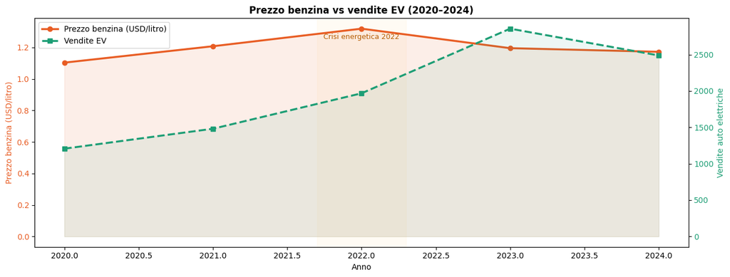

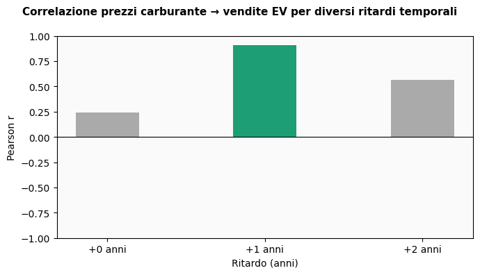

```
 lag (anni)  Pearson r  p-value
          0      0.240   0.6975
          1      0.907   0.0933
          2      0.567   0.6166

→ Il lag con correlazione più forte è: 1 anno/i
```

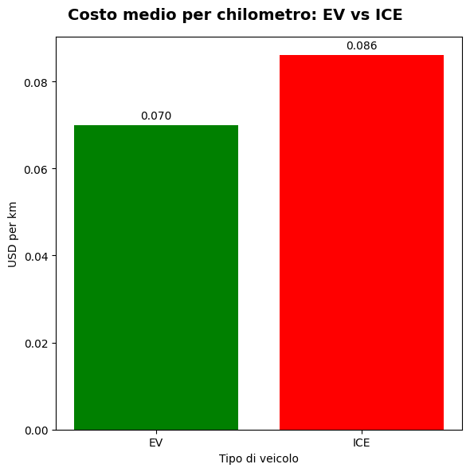

```
Media ICE (km/kWh): 1.64
2020: EV mean = 7.28
2021: EV mean = 7.26
2022: EV mean = 7.00
2023: EV mean = 7.16
2024: EV mean = 6.92
```

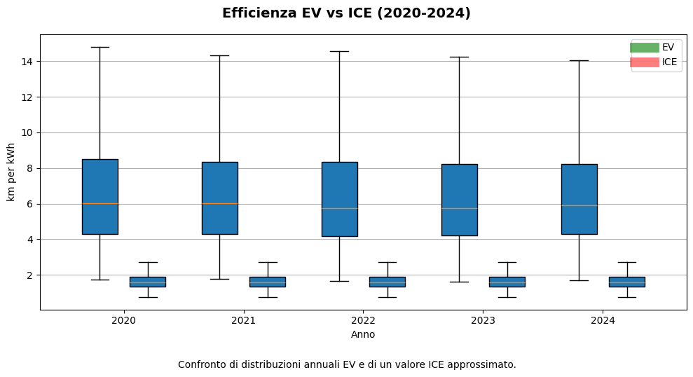

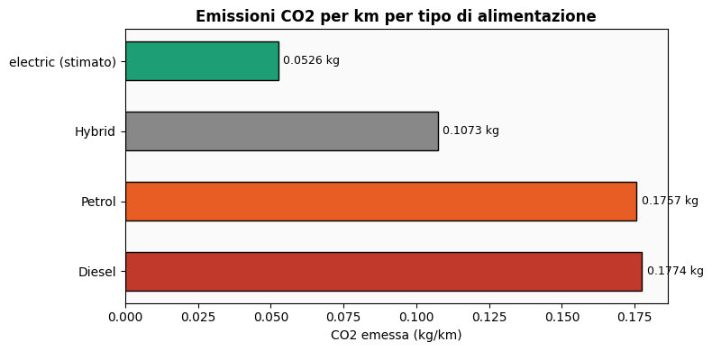

## 🎯 Risposta finale

L’aumento dei prezzi dei carburanti è un **fattore rilevante**,  
ma agisce insieme ad altri elementi nel guidare la transizione verso i veicoli elettrici.